# Lista 4

```r
library(tidyverse)
library(dplyr)
library(gapminder)
library(socviz)
```

A maneira com a qual decidi seguir com esse trabalho, foi realizar todos os gráficos, fazendo modificações pequenas, tais como adicionar um tema, e nos “mais importantes” - os que sumarizam a maior parte do conteúdo - decidi realizar modificações maiores, tais como mudar as cores.

# 1 Agrupando os dados

Muitas das vezes, precisamos entender melhor como o R funciona para conseguirmos fazer exatamente o que queremos. No exemplo a seguir, tentamos realizar uma plot do gráfico de linhas para cada país em relação ao ano. No entanto, o output não é o gráfico que desejamos. Veja a seguir:

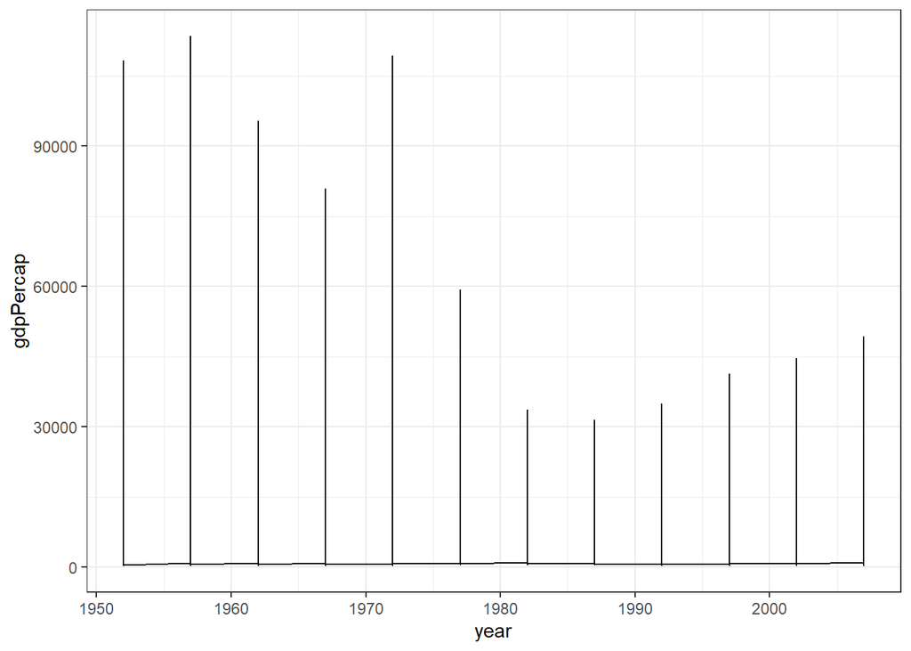

```r
p <- ggplot(data = gapminder, mapping = aes(x = year, y = gdpPercap))
p + geom_line() + theme_bw()
```

Isso ocorreu pois apenas pedimos para o R separar por anos, e não por países, assim como gostariamos. Assim, devemos explicar explicitamente o que queremos para plotarmos o gráfico certo. Podemos especificar, dizendo para dividir cada ano por país.

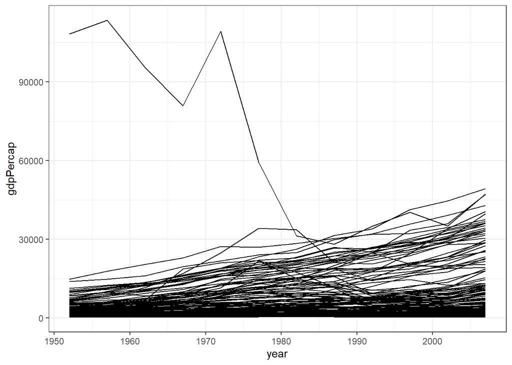

```r
p + geom_line(aes(group = country)) + theme_bw()
```